# 1_Intro_Machine_Learning_1

**Coursebook: Introduction to Machine Learning 1**

- Part 5 of Data Analytics Specialization
- Course Length: 12 Hours
- Last Updated: July 2024
- Developed by [Algoritma](https://algorit.ma)'s product division and instructors team

# Background

The coursebook is part of the **Python Machine Learning** prepared by [Algoritma](https://algorit.ma). The coursebook is intended for a restricted audience only, i.e. the individuals and organizations having received this coursebook directly from the training organization. It may not be reproduced, distributed, translated or adapted in any form outside these individuals and organizations without permission.

Algoritma is a data science education center based in Jakarta. We organize workshops and training programs to help working professionals and students gain mastery in various data science sub-fields: data visualization, machine learning, data modeling, statistical inference etc.

# Introduction to Machine Learning 1

## Training Objective

- Basic Principles of Machine Learning
  - What is Data, Types of Data, Component of Data in the Scikit-learn
  - Why Machine Learning?
  - Load Data & Exploratory Data Analysis
- Data Preprocessing
  - Handling Numerical Data
  - Handling Categorical Data
- Train-test Splitting
  - Why Train-Test Splitting?
  - How to Train-Test Splitting
- Implementation SVM
  - Introduction to Support Vector Machine (SVM)
  - SVM in Classification
  - SVM in Regression
- Model Improvement Technique
  - Model Evaluation
  - Hyperparameters SVM

## Introduction

In today's digital age, data has become an integral part of our lives. Every time we browse the internet, make a purchase, or use a social media platform, we generate enormous amounts of data. This data contains valuable insights that can help businesses make informed decisions and improve their operations. However, analyzing this data can be a daunting task, especially when dealing with vast amounts of unstructured data.

Businesses face various challenges in analyzing data, such as **identifying patterns and trends, making predictions, and extracting insights**. Traditional methods of data analysis, such as manual data entry and basic statistical analysis, are **time-consuming** and often insufficient in dealing with large datasets. Additionally, the sheer volume of data generated every day makes it nearly impossible for humans to process and analyze it all.

This is where machine learning comes in. By leveraging advanced algorithms, machine learning can help businesses analyze large datasets **quickly and efficiently**. Machine learning algorithms can identify patterns and relationships in data, make predictions, and learn from past experiences to improve their performance over time. This makes it a powerful tool for businesses looking to gain insights and make data-driven decisions.

With the increasing availability of data and the rapid advancements in machine learning technology, businesses that fail to leverage this powerful tool risk falling behind their competitors. Therefore, it is crucial for businesses to embrace machine learning and invest in the development of machine learning models to stay ahead in today's data-driven world.

## What is Machine Learning

Machine learning is a sub-field of computer science that involves the development of algorithms that **enable computers to learn from data without being explicitly programmed**. In other words, machine learning allows computers to improve their performance over time by learning from experience.

At its core, machine learning is a research field that sits at the intersection of statistics, artificial intelligence, and computer science. It has its roots in the study of pattern recognition and computational learning theory, and has since grown to encompass a wide range of applications in areas such as natural language processing, computer vision, and robotics.

Machine learning algorithms can be broadly classified into two types: supervised and unsupervised learning. Supervised learning involves training a machine learning model on labeled data, where the correct output is already known. Unsupervised learning, on the other hand, involves training a model on unlabeled data, where the correct output is unknown.

The application of machine learning methods has become increasingly ubiquitous in everyday life. From automatic movie recommendations, to suggestions of food and products based on our shopping history, to personalized music streaming services and recognizing our friends in digital photos, many modern apps and services have machine learning algorithms at their core. When we look at a complex website like Facebook, Amazon, or Netflix, it is very likely that every part of their service contains multiple machine learning models.

**Traditional Programming vs Machine Learning**

[figure not shown]

## Why Machine Learning?

In the early days of "intelligent" applications, many systems used handcoded rules of "if" and "else" decisions to process data or adjust to user input.

Think of a spam filter whose job is to move the appropriate incoming email messages to either the inbox or a spam folder. We could make up a blacklist of words that would result in an email being marked as spam. This would be an example of using an expert-designed rule system to design an "intelligent" application. Manually crafting decision rules is feasible for some applications, particularly those in which humans have a good understanding of the process to model.

[figure not shown]

However, using handcoded rules to make decisions has two major disadvantages:

- The logic required to make a decision is specific to a single domain and task. Changing the task even slightly might require a rewrite of the whole system.
- Designing rules requires a deep understanding of how a decision should be made

**Another Example**

One example of where this handcoded approach will fail is in detecting faces in images. Today, every smartphone can detect a face in an image. However, face detection was an unsolved problem until as recently as 2001. The main problem is that the way in which pixels (which make up an image in a computer) are "perceived" by the computer is very different from how humans perceive a face. This difference in representation makes it basically impossible for a human to come up with a good set of rules to describe what constitutes a face in a digital image.

But, using machine learning, however, simply presenting a program with a large collection of images of faces is enough for an algorithm to determine what characteristics are needed to identify a face.

# How Machine Learning Works

We know that, we need **input** and **output** to create a machine learning model. For example, in the case of wanting to predict this house price range class, **which column will be the output or target variable** in the machine learning model?

| Bedrooms | AreaInMtrSqr | Floors | ZipCode | Price Range |
| --- | --- | --- | --- | --- |
| 3 | 120 | 1.0 | 98178 | Low-class |
| 3 | 60 | 2.0 | 98125 | High-class |
| 2 | 200 | 1.0 | 98028 | Middle-class |
| 4 | 140 | 1.0 | 98074 | High-class |

In the machine learning case that we will discuss, those will be

#### Features/Predictor

Predictor variables, also known as feature variables, are the input variables used in a machine learning model to make predictions about the target variable. These variables are typically represented as columns in a dataset, and can take on different types of data, including numerical data (such as the number of bedrooms in a house), categorical data (such as the zip code of a house), or text data (such as a description of a product).

In the context of predicting house prices, some examples of predictor variables could be the number of bedrooms, the area in square meters, the number of floors, and the zip code of a house. These variables are used by the machine learning model to try to identify patterns and relationships that exist between them and the target variable, which is the variable we want to predict.

#### Target variables

The target variable, also known as the response variable or dependent variable, is the variable that we want to predict using the predictor variables. In the case of predicting house prices, the target variable could be the actual price of a house, or a categorical variable indicating the price range of a house (such as high, medium, or low).

In the machine learning model, the target variable is the variable that the model is trying to learn to predict based on the input provided by the predictor variables. The goal of the machine learning model is to find the relationship between the predictor variables and the target variable, so that it can accurately predict the target variable for new, unseen data.

## Predictive Analytics in ML: Classification & Regression

The following depicts a **classification** task: the figure shows a collection of two-dimensional data, colored according to their respective class labels. A classification algorithm may be used to draw a dividing boundary between the two clusters of points:

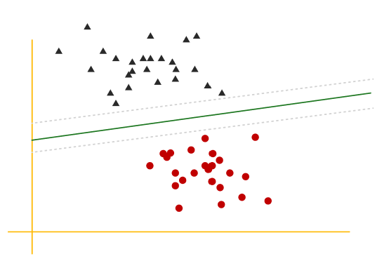

**Classification** problems refer to situations where the value we’re trying to predict is categorical (loan defaults, email spam collection, handwriting recognition etc).

The next task we’ll look at is a regression problem: a simple best-fit line to a set of data:

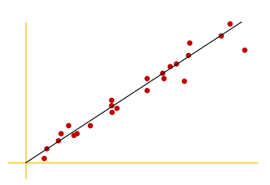

Again, this is an example of fitting a model to data, and the resulting model can make generalizations toward new, unseen data. We then say that this model had "learnt" from the training data, and can be used to predict the result of test data: here, we might feed it a value ("x"), and the model would allow us to predict the corresponding output ("y").

**Regression** task refers to situation where we want to predict numerical value; That is, when our target output is numeric (think oil prices, rainfall, quarterly sales, blood pressure etc)

## Knowledge Check: Classification & Regression

1. A company T is wanting to determine the approximate price of a new car to be sold. In order not to set the wrong price, he wants to determine it based on historical data on the prices of the cars sold, which are influenced by their features (such as air conditioning, engines, quality, etc.). Where is this case?

[figure not shown]

> **Answer:**
2. There is a dataset of iris flowers, and we want to predict which flower with certain characteristics belongs to which iris flower type.

[figure not shown]

> **Answer:**
3. If we have a handwritten dataset of digit numbers from 0 to 9, and then we want to predict what number an image is, then this case is included in the classification and regression case?

[figure not shown]

> **Answer:**

# Machine Learning Workflow

## Scikit-Learn Introduction

To perform machine learning analysis, one needs access to relevant algorithms and tools. One of the most widely used libraries for machine learning in Python is **scikit-learn**, also known as **sklearn**. This library is essential for anyone who wants to build machine learning models and perform data analysis using Python.

Scikit-learn includes a broad range of algorithms for tasks such as classification, regression, clustering, and dimensionality reduction. It also provides tools for data preprocessing, model selection, and evaluation. These features make scikit-learn a comprehensive toolkit for building machine learning pipelines.

Using scikit-learn in combination with other Python libraries like NumPy and Pandas allows for efficient data manipulation and analysis, providing a powerful environment for machine learning tasks. Whether we are a beginner or an experienced data scientist, scikit-learn is an essential tool for aor machine learning toolkit.

The documentation is here: https://scikit-learn.org/stable/.

```python
import sklearn
```

## Load Data: Employee Turnover Dataset

The [Employee Turnover Dataset](https://www.kaggle.com/datasets/tawfikelmetwally/employee-dataset/data) will be used in the following practice. This dataset contains information on employees from a company in India, including their educational backgrounds, work history, demographics, and employment-related factors.

The challenge here is to **gain insightful foresights into employee turnover by predicting employees at high risk of leaving**. This requires building a classification model that can predict the likelihood of an employee deciding to leave the company based on their characteristics.

To achieve this, we will need to analyze the Employee Turnover Dataset, which includes information on various employee features, such as education, joining year, city, payment tier, age, gender, and years of experience.

We will use the classification technique to accomplish this task, where the goal is to classify the employees into two categories, i.e., employees that have left the company or not.

```python
import pandas as pd
import numpy as np
import matplotlib.pyplot as plt
```

```python
employees = pd.read_csv("data_input/employees.csv")
employees.head()
```

|  | EmployeeId | Education | City | PaymentTier | Age | Gender | EverBenched | ExperienceInCurrentDomain | Status |
| --- | --- | --- | --- | --- | --- | --- | --- | --- | --- |
| 0 | I1-84894 | Bachelors | Bangalore | 3 | 34 | Male | No | 0 | Left |
| 1 | I3-14270 | Bachelors | Pune | 1 | 28 | Female | No | 3 | Active |
| 2 | I2-66215 | Bachelors | New Delhi | 3 | 38 | Female | No | 2 | Left |
| 3 | I1-73250 | Masters | Bangalore | 3 | 27 | Male | No | 5 | Active |
| 4 | I3-85771 | Masters | Pune | 3 | 24 | Male | Yes | 2 | Active |

**Data Description**

- `Employee ID` : Unique identifier of each employees
- `Education`: The educational qualifications of employees.
- `City`: The city where each employee works.
- `Payment Tier`: Categorization of employees into different salary tiers.
- `Age`: The age of each employee.
- `Gender`: Gender identity of employees.
- `Ever Benched`: Indicates if an employee has ever been temporarily without assigned work.
- `Experience` The number of years of experience employees have in their current field.

*output variable (desired target):*

- `Status`: The indicator that the employee has left the company.

```python
employees.shape
```

```
(4653, 9)
```

## Exploratory Data Analysis

To gain insights into the data and know data condition so we can select appropriate techniques in the next step, we need to do exploratory data analysis (EDA)

How is the data type of each column in the data? Is it appropriate?

```python
employees.info()
```

```
<class 'pandas.core.frame.DataFrame'>
RangeIndex: 4653 entries, 0 to 4652
Data columns (total 9 columns):
 #   Column                     Non-Null Count  Dtype
---  ------                     --------------  -----
 0   EmployeeId                 4653 non-null   object
 1   Education                  4653 non-null   object
 2   City                       4653 non-null   object
 3   PaymentTier                4653 non-null   int64
 4   Age                        4653 non-null   int64
 5   Gender                     4653 non-null   object
 6   EverBenched                4653 non-null   object
 7   ExperienceInCurrentDomain  4653 non-null   int64
 8   Status                     4653 non-null   object
dtypes: int64(3), object(6)
memory usage: 327.3+ KB
```

**It is important to ensure that the data type in each column is appropriate** because the data type determines how the data is stored and how it can be used. **If the data type is not appropriate, it can lead to misinterpretations by the model or incorrect results**.

For example, if a numerical variable is stored as a string data type, the model may not be able to perform mathematical operations on it, which can lead to errors in the analysis. Similarly, if a categorical variable is stored as a numerical data type, the model may treat it as a continuous variable, which can lead to incorrect results.

```python
# list all numeric columns
num_features = ['Age', 'ExperienceInCurrentDomain']

# List all categorical columns
cat_features = ['PaymentTier', 'Status', 'City', 'EverBenched', 'Education', 'Gender']
```

```python
# change datatype to categorical
employees[cat_features] = employees[cat_features].astype('category')
```

What are the characteristics of our data? Such as the age and years of experience of our employees.

```python
employees.describe()
```

|  | Age | ExperienceInCurrentDomain |
| --- | --- | --- |
| count | 4653.000000 | 4653.000000 |
| mean | 29.393295 | 2.905652 |
| std | 4.826087 | 1.558240 |
| min | 22.000000 | 0.000000 |
| 25% | 26.000000 | 2.000000 |
| 50% | 28.000000 | 3.000000 |
| 75% | 32.000000 | 4.000000 |
| max | 41.000000 | 7.000000 |

**Insight :**

- Employee age range from 22 years old to 41 years old
- The highest number of employee's years of experience are 7 years

How about the categorical data?

```python
employees.describe(include='category')
```

|  | Education | City | PaymentTier | Gender | EverBenched | Status |
| --- | --- | --- | --- | --- | --- | --- |
| count | 4653 | 4653 | 4653 | 4653 | 4653 | 4653 |
| unique | 3 | 3 | 3 | 2 | 2 | 2 |
| top | Bachelors | Bangalore | 3 | Male | No | Left |
| freq | 3601 | 2228 | 3492 | 2778 | 4175 | 3053 |

**Insight :**

- The most common education level is a Bachelor's degree
- There are three unique cities where the employees works. The most common city is Bangalore.
- There are more male employees than female employees

### Visualize the Data

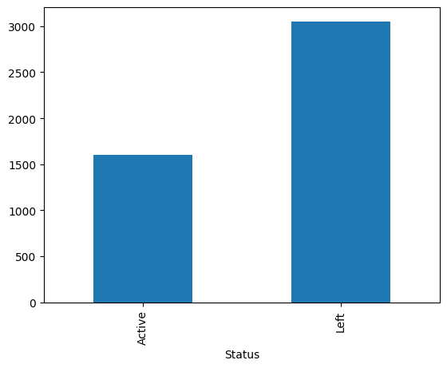

```python
employees['Status'].value_counts(ascending=True).plot(kind='bar');
```

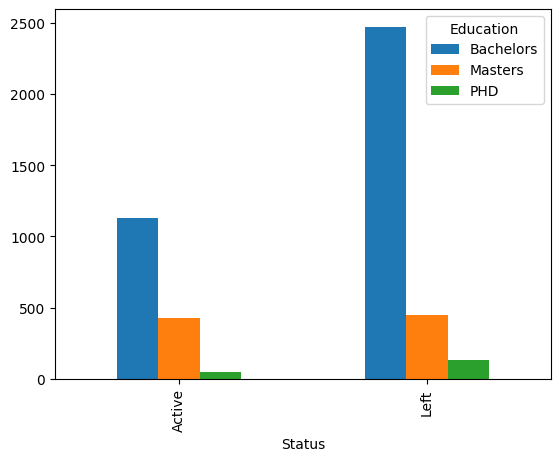

```python
pd.crosstab(
	index=employees['Status'],
	columns=employees['Education']
).plot(kind='bar');
```

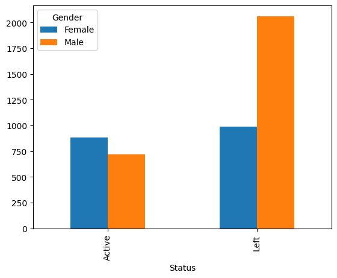

```python
pd.crosstab(
	index=employees['Status'],
	columns=employees['Gender']
).plot(kind='bar');
```

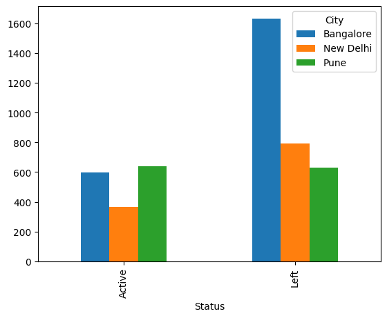

```python
pd.crosstab(
	index=employees['Status'],
	columns=employees['City']
).plot(kind='bar');
```

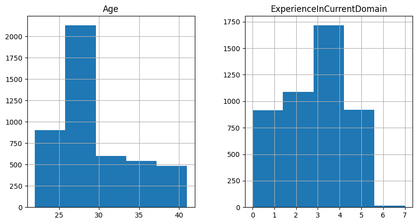

```python
employees.hist(bins=5, figsize=(10,5));
```

By visualizing the Employee Turnover Dataset, it is worth noting that the majority of the employees has left the company. We can see that employees with bachelor's degrees represent a significant portion of those who have left, males are leaving more frequently than females, and employees in Bangalore have the highest turnover compared to the other cities. The age of the majority of employees are distributed around the range of 25-30 years old with 3-4 years of experience in their domain.

These insights can be used to predict employees at high risk of leaving more effectively. For example, The company could indicate potential issues such as underemployment, lack of growth opportunities, or dissatisfaction from the bachelor's degree employee or the employers in Bangalore might need to focus more on competitive pay, benefits, and career development opportunities. By closely analyzing the factors associated with employee turnover and addressing them proactively through targeted strategies, companies can better manage retention and create a more stable workforce.

## Data Preprocessing

### Check Missing Values

It is important to check for missing values in a dataset before using machine learning algorithms because missing data can have a significant impact on the performance and accuracy of the machine learning models. Missing values can occur in a dataset due to a variety of reasons such as data collection errors, data processing issues, or simply because the data was not collected for certain observations.

Machine learning algorithms typically require complete datasets to be able to learn and make accurate predictions. If there are missing values in the dataset, the algorithm may not be able to make accurate predictions or may result in biased results.

In addition, some machine learning algorithms do not handle missing values well and may either fail or introduce additional bias into the model. Therefore, it is important to handle missing values appropriately before applying machine learning algorithms. This can include imputing missing values using various techniques such as mean imputation, median imputation, or using machine learning models to predict missing values.

Overall, checking for and handling missing values is a critical step in the data preprocessing stage before applying machine learning algorithms.

```python
employees.isnull().sum()
```

```
EmployeeId                   0
Education                    0
City                         0
PaymentTier                  0
Age                          0
Gender                       0
EverBenched                  0
ExperienceInCurrentDomain    0
Status                       0
dtype: int64
```

There are no missing values. If our dataset in another project has missing values, it can be handled in several ways:

1. Delete rows with missing values
2. Replace the missing values with statistical values (e.g., average, mode for category).
3. Use the ML model to find the missing values, for example, MICE (Multiple Imputation by Chained Equation) or KNN Imputation.

### Check Duplicates Values

It is important to check for duplicate data before using machine learning because duplicates can affect the accuracy of the machine learning model. When there are duplicate records in the dataset, it can result in a biased model as the model may give more importance to these duplicate records. This can result in overfitting, which means that the model is too complex and has learned the noise in the data instead of the underlying pattern.

Furthermore, duplicate data can lead to inaccurate results when performing statistical analysis on the dataset. This is because the duplicate data inflates the sample size and therefore, the statistical analysis may overestimate the true significance of the results.

Therefore, it is important to identify and remove duplicate data before training the machine learning model. This can be done by checking for duplicate rows or duplicate columns in the dataset. If duplicate data is found, it can either be removed or merged with the original data, depending on the context of the problem and the nature of the duplicates.

```python
employees.duplicated().sum()
```

```
0
```

The dataset is clean enough. If our dataset in another project has duplicated values, handling duplicate values can depend on the context in which they occur, but here are several general ways to handle them:

1. Remove duplicates: One way to handle duplicates is to remove them altogether. This can be useful if we only need the unique values in a data set or if duplicates are causing issues in a program.
2. Keep only one copy of duplicates: Another approach is to keep only one copy of each duplicate value. This can be useful if we want to preserve some information from the duplicates, such as the first or last occurrence.

### Handle Numerical Data: Outliers

Handling outliers in numerical data is an important step in machine learning, as these extreme values can significantly affect the performance of a model. Outliers are data points that lie far away from the majority of the data points and may arise due to measurement errors, data entry errors, or other anomalies. These outliers can skew the distribution of the data and cause issues in modeling, such as overfitting.

There are several techniques to handle outliers in numerical data. One approach is to remove the outliers altogether, but this can result in a loss of important information and may not be feasible if the dataset is small. Another approach is to treat the outliers as missing values and impute them with a suitable value. This can be done by replacing the outliers with the median or mean of the data or just keeping it to gain rich information about the data.

By using statistical methods such as z-score or interquartile range (IQR) to detect and handle the outliers. The z-score method identifies outliers based on their distance from the mean while IQR method identifies outliers based on their distance from the first and third quartiles. These methods can help identify and handle outliers more accurately.

Let's check our numerical variable using boxplot:

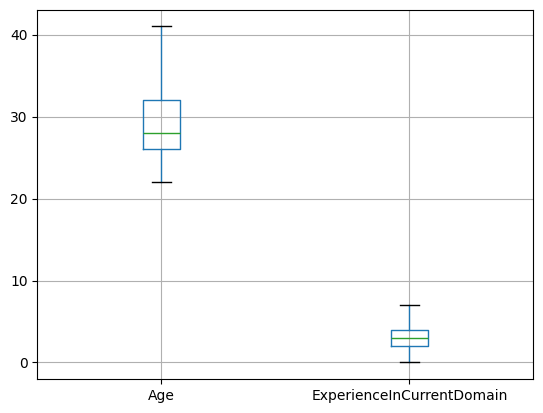

```python
employees.boxplot(column=num_features);
```

**Insight:** There are no outlier in our data.

If our dataset in another project has outlier value, here are several ways to handle outliers in Python:

Remember, the choice of approach depends on your specific goals and the nature of your data. By considering these different methods, you can decide how to handle outliers while prioritizing the retention of their valuable information for your model.

1. **Correct Value**: Correcting a data point to its proper value. Let's say you have a dataset that records the heights of individuals. The data is supposed to be in meters, but there was an error during data entry, and someone mistakenly input the values in centimeters. For instance, the height of a person is recorded as 170, which should be interpreted as 170 centimeters instead of the intended 170 meters. To correct this error and convert the height to the proper value in meters, you need to divide the recorded value by 100. In this case, the corrected height would be 1.70 meters.
2. **Remove Outliers**: One way to handle outliers is by selectively removing extreme values from the dataset. However, this method may result in a loss of data and potentially biased results.
3. **Replacing with Statistical Measures**: Instead of removing outliers, you can replace them with more representative values derived from statistical measures. Calculate the median or other robust statistical measures that are less sensitive to outliers, and use them as replacements for outliers while retaining the rest of the dataset unchanged. This method make them less extreme and this technique suitable for small datasets with numerous outliers that negatively impact the model's performance. But, care should be taken to consider the implications of modifying the original data!!!
4. **Keeping Outliers as They Are**: If you want to preserve the outliers without modifying them, you can simply do nothing. Leave the outliers as they are in the dataset, and include them in your analysis without any alterations. This approach acknowledges the rich information contained in outliers and allows your model to learn from their unique patterns.

Overall, by choosing to keep outliers as they are, you will more prioritize gaining rich information that can enhance your business insights and provide a more accurate representation of the underlying data distribution.

Reference:

- [Best-Practice Recommendations for Defining, Identifying, and Handling Outliers](http://www.hermanaguinis.com/ORMoutliers.pdf)
- [How to Detect and Handle Outliers](https://hwbdocuments.env.nm.gov/Los%20Alamos%20National%20Labs/TA%2054/11587.pdf)

[figure not shown]

The above plot is referred to as a box plot, also known as a box-and-whisker plot, is a graphical representation of the distribution of a dataset. The box plot depicts the five-number summary as follows:

- Q1: the first quartile (25th percentile of the data)
- Median: the second quartile (50th percentile of the data)
- Q3: the third quartile (75th percentile of the data)
- Lower whisker: the lower fence
- Upper whisker: the upper fence
- Data outside the fences are considered outliers.

**Warning**, The lower whisker is not the minimum value of the data, and the upper whisker is not the maximum value of the data.

When a box plot includes outliers, they are typically represented as individual points that are plotted outside of the whiskers. Outliers are important to identify because they may represent extreme or unusual values that can have a significant impact on the interpretation of the data.

To identify outliers, there are some methods, such as

- **IQR method**: This method involves identifying the interquartile range (IQR) of the data and removing any values outside of a specified range. The IQR is defined as the difference between the third quartile (75th percentile) and the first quartile (25th percentile). Any value that is more than 1.5 times the IQR away from the quartiles is considered an outlier.
- **Z-score method**: This method involves calculating the z-score of each data point, which measures how many standard deviations away from the mean the data point is. Any data point with a z-score greater than a specified threshold (e.g., 3) is considered an outlier. We can use the zscore function from the scipy.stats module to calculate the z-scores

```python
# this code can be your reference if want check which one is outlier
Q1 = employees[num_features].quantile(0.25)
Q3 = employees[num_features].quantile(0.75)
IQR = Q3 - Q1
outlier_mask = ((employees[num_features] < (Q1 - 1.5 * IQR)) | (employees[num_features] > (Q3 + 1.5 * IQR)))
total_rows_with_outliers = len(employees[outlier_mask.sum(axis=1) > 0])

print("Total rows with outliers: ", total_rows_with_outliers, "rows or around ",
      round(total_rows_with_outliers/employees.shape[0], 2), "%")
```

```
Total rows with outliers:  0 rows or around  0.0 %
```

**Insight:** Given that our dataset is large and **the percentage of outliers is 0%, we decided to keep the dataset as they are**.

### Handle Categorical Data: Encoding

[figure not shown]

Categorical data refers to data that is divided into groups or categories, where each observation belongs to a particular category. In machine learning, categorical data is an essential part of many datasets and can provide valuable insights into the behavior of a system or the characteristics of a group.

Categorical data can be further divided into two types: **nominal and ordinal**. Nominal data refers to data that is not ordered or ranked, such as gender or eye color. On the other hand, ordinal data refers to data that is ordered or ranked, such as education level or income bracket.

Handling categorical data in machine learning is essential as most machine learning algorithms **require numerical input data**. There are several ways to handle categorical data in machine learning, including one-hot encoding, label encoding, and target encoding.

- **One-hot encoding** is a process of representing categorical data as binary vectors, where each category is represented by a binary digit (0 or 1) in a vector. *For example, if we have a categorical feature "color" with three possible values - red, green, and blue, one hot encoding would represent these values as [1,0,0], [0,1,0], and [0,0,1] respectively.* One hot encoding is useful for algorithms that cannot handle categorical data directly, such as linear regression or support vector machines.
- **Label encoding** is another method of encoding categorical data where each category is assigned a unique numerical value. *For example, if we have a categorical feature "color" with three possible values - red, green, and blue, label encoding would represent these values as 1, 2, and 3, respectively.* However, label encoding assumes an ordinal relationship between the categories, meaning that the numerical values assigned to each category imply an order or ranking. This can lead to issues if the categories do not have a natural order, such as with the colors red, green, and blue.
- **Ordinal encoding** is similar to label encoding, but instead of assigning arbitrary numerical values to the categories, the values are assigned based on their rank or order. *For example, if we have a categorical feature "size" with three possible values - small, medium, and large, ordinal encoding would represent these values as 1, 2, and 3, respectively*. Unlike label encoding, ordinal encoding is appropriate when there is a natural order to the categories.

In summary, handling categorical data in machine learning is important because many algorithms cannot handle categorical data directly. One hot encoding is a method that represents categorical data as binary vectors, while label encoding and ordinal encoding are methods that assign numerical values to each category. Label encoding assumes an ordinal relationship between the categories, while ordinal encoding assigns values based on their rank or order. By handling categorical data correctly, machine learning algorithms can use this information effectively to make accurate predictions or classifications.

```python
cat_features
```

```
['PaymentTier', 'Status', 'City', 'EverBenched', 'Education', 'Gender']
```

```python
employees['Education'].unique()
```

```
['Bachelors', 'Masters', 'PHD']
Categories (3, object): ['Bachelors', 'Masters', 'PHD']
```

#### One-Hot Encoding

One of the ways to do one-hot encoding in Python is by using the `pd.get_dummies()` method from the Pandas library.

`pd.get_dummies()` takes a DataFrame or Series containing categorical data as input and returns a new DataFrame with the categorical variables replaced by binary (0/1) columns representing the presence or absence of a particular category.

For example, suppose we have a dataset with a categorical variable `color` that can take on the values 'red', 'green', and 'blue'. We can apply one-hot encoding to this variable using `pd.get_dummies()` as follows:

```
{python}
data = {'color': ['red', 'green', 'blue', 'red', 'green']}
df = pd.DataFrame(data)

encoded_df = pd.get_dummies(df['color'])
```

The resulting `encoded_df` DataFrame will have three columns, one for each category in the `color` variable:

```
{python}
   blue  green  red
0     0      0    1
1     0      1    0
2     1      0    0
3     0      0    1
4     0      1    0
```

Each row in the new DataFrame represents a single observation from the original dataset, with 1s indicating the presence of a particular category and 0s indicating its absence.

One-hot encoding is particularly useful when dealing with nominal categorical data, where there is no inherent ordering between categories.

```python
employees = pd.get_dummies(employees, columns = ['EverBenched', 'Gender', 'Status'], drop_first=True, dtype='int64')
employees
```

|  | EmployeeId | Education | City | PaymentTier | Age | ExperienceInCurrentDomain | EverBenched_Yes | Gender_Male | Status_Left |
| --- | --- | --- | --- | --- | --- | --- | --- | --- | --- |
| 0 | I1-84894 | Bachelors | Bangalore | 3 | 34 | 0 | 0 | 1 | 1 |
| 1 | I3-14270 | Bachelors | Pune | 1 | 28 | 3 | 0 | 0 | 0 |
| 2 | I2-66215 | Bachelors | New Delhi | 3 | 38 | 2 | 0 | 0 | 1 |
| 3 | I1-73250 | Masters | Bangalore | 3 | 27 | 5 | 0 | 1 | 0 |
| 4 | I3-85771 | Masters | Pune | 3 | 24 | 2 | 1 | 1 | 0 |
| ... | ... | ... | ... | ... | ... | ... | ... | ... | ... |
| 4648 | I1-56353 | Bachelors | Bangalore | 3 | 26 | 4 | 0 | 0 | 1 |
| 4649 | I3-43305 | Masters | Pune | 2 | 37 | 2 | 0 | 1 | 0 |
| 4650 | I2-45787 | Masters | New Delhi | 3 | 27 | 5 | 0 | 1 | 0 |
| 4651 | I1-85626 | Bachelors | Bangalore | 3 | 30 | 2 | 1 | 1 | 1 |
| 4652 | I1-65569 | Bachelors | Bangalore | 3 | 33 | 4 | 1 | 1 | 1 |

4653 rows × 9 columns

#### Label Encoding

Label Encoding is a technique to convert categorical variables into numerical variables. In pandas, we can use the **`cat.codes`** attribute to perform Label Encoding. This attribute assigns a unique integer to each unique value in a categorical variable. To use `cat.codes`, we need to first convert the categorical variable to a pandas `Categorical` data type using the `astype` method. Once we have done this, we can then use the `cat.codes` attribute to perform the label encoding.

```python
# example: encode the categorical variable using the cat.codes attribute
employees['City'].astype('category').cat.codes
```

```
0       0
1       2
2       1
3       0
4       2
       ..
4648    0
4649    2
4650    1
4651    0
4652    0
Length: 4653, dtype: int8
```

```python
dict( enumerate(employees['City'].astype('category').cat.categories ) )
```

```
{0: 'Bangalore', 1: 'New Delhi', 2: 'Pune'}
```

```python
employees = pd.get_dummies(employees, columns = ['City'], drop_first=True, dtype='int64')
employees
```

|  | EmployeeId | Education | PaymentTier | Age | ExperienceInCurrentDomain | EverBenched_Yes | Gender_Male | Status_Left | City_New Delhi | City_Pune |
| --- | --- | --- | --- | --- | --- | --- | --- | --- | --- | --- |
| 0 | I1-84894 | Bachelors | 3 | 34 | 0 | 0 | 1 | 1 | 0 | 0 |
| 1 | I3-14270 | Bachelors | 1 | 28 | 3 | 0 | 0 | 0 | 0 | 1 |
| 2 | I2-66215 | Bachelors | 3 | 38 | 2 | 0 | 0 | 1 | 1 | 0 |
| 3 | I1-73250 | Masters | 3 | 27 | 5 | 0 | 1 | 0 | 0 | 0 |
| 4 | I3-85771 | Masters | 3 | 24 | 2 | 1 | 1 | 0 | 0 | 1 |
| ... | ... | ... | ... | ... | ... | ... | ... | ... | ... | ... |
| 4648 | I1-56353 | Bachelors | 3 | 26 | 4 | 0 | 0 | 1 | 0 | 0 |
| 4649 | I3-43305 | Masters | 2 | 37 | 2 | 0 | 1 | 0 | 0 | 1 |
| 4650 | I2-45787 | Masters | 3 | 27 | 5 | 0 | 1 | 0 | 1 | 0 |
| 4651 | I1-85626 | Bachelors | 3 | 30 | 2 | 1 | 1 | 1 | 0 | 0 |
| 4652 | I1-65569 | Bachelors | 3 | 33 | 4 | 1 | 1 | 1 | 0 | 0 |

4653 rows × 10 columns

But, the label encoding assigns numerical labels to categories based on an arbitrary order. In the case of the `City` column. This numerical representation may inadvertently introduce a misleading sense of order or hierarchy among the categories. For example, if we label categories as 0, 1, and 2, the model might incorrectly assume that category 2 is greater than category 1, which can lead to incorrect interpretations or biased predictions. Or the model may incorrectly infer relationships or patterns that don't actually exist.

While one-hot encoding increases dimensionality, it provides a more accurate representation of categorical variables and allows models to capture the unique characteristics of each category. One-hot encoding avoids these issues by creating separate binary columns for each category, treating them independently and preserving the categorical nature of the data. It also ensures equal importance and avoids distorting distances or relationships between categories.

#### Ordinal Encoding

In this example, we can encode ordinal categories by mapping the categories to their corresponding integer order. First, we will see the current order of categories in our ordinal column `Education`:

```python
employees['Education'].cat.categories
```

```
Index(['Bachelors', 'Masters', 'PHD'], dtype='object')
```

Based on the original order, notice that it is already in the correct order based on the employees' education levels: bachelors, masters, and PhD. Therefore, we can encode the categories by replacing them using the `.cat.rename_categories()` method with a list of integers based on the categories' order:

```python
employees['Education'] = employees['Education'].cat.rename_categories([0, 1, 2])
employees['Education'].head()
```

```
0    0
1    0
2    0
3    1
4    1
Name: Education, dtype: category
Categories (3, int64): [0, 1, 2]
```

## Train-Test Splitting

Before we start building a machine learning model, it's important to split our data into training and testing sets. This process is known as train-test splitting. The purpose of train-test splitting is to evaluate the performance of our model on **unseen data**.

Train-test splitting is a crucial step in the machine learning process that helps to evaluate the performance of a model on unseen data. It is typically used when we have a dataset and want to build a machine learning model to make predictions or classify new observations. In general, we need to perform train-test splitting whenever we want to estimate how well a machine learning model will perform on new data. This can occur in a variety of situations, such as developing a predictive model for customer churn, building a recommendation system, or classifying data.

Without train-test splitting, we may develop a model that performs well on the training data but fails to generalize to new, unseen data. This is known as overfitting and can result in poor model performance. Therefore, it's important to split the data into training and testing sets to evaluate the model's performance on new data. Additionally, train-test splitting can help us to choose the best machine learning algorithm or hyperparameters for a given problem. By evaluating the performance of different models on the testing set, we can select the one that performs the best on unseen data.

To perform train-test splitting, we randomly divide the dataset into two sets - a training set and a testing set. The training set is used to train the model, while the testing set is used to evaluate the model's performance. The testing set should be **representative** of the overall data and should **not be used in any way during the training process** to prevent overfitting.

[figure not shown]

Before we can do train-test splitting, we need to separate our dataset into two parts, the target variable (`y`) and the predictor variable (`X`).

- `y` : Stores the target column of the dataset
- `X` : Stores the predictor columns, which is all the columns except the target column and the unique identifier column.

```python
y = employees['Status_Left']
X = employees.drop(['Status_Left', 'EmployeeId'], axis=1)
```

The `EmployeeId` column is a unique identifier, therefore it doesn't hold relevant information about employee characteristics that would help the model to learn.

We can split the dataset using the `train_test_split()` function, therefore we are going to import it first.

```python
# import train_test_split function from sklearn.model_selection module
from sklearn.model_selection import train_test_split
```

We can use `train_test_split` with the following parameters.

- `*arrays`: dataframes that we use (separated, for predictors and target variables)
- `test_size`: the percentage of data to be used as test data.
- `train_size`: the percentage of data to be used as test data (will be filled automatically if `test_size` is assigned a value)
- `random_state`: random number generator (RNG) value. If we enter an integer value for this parameter, it will produce the same result for the same value. If we change the value, then the result will be different.

> **NOTES**: The most common method of train-test splitting involves using 80% of the data for training and the remaining 20% for testing. However, the split ratio can vary depending on the size of the dataset and the specific problem at hand.

```python
# split dataset into training set and test set
X_train, X_test, y_train, y_test = train_test_split(X,
                                                    y,
                                                    test_size = 0.2, # 80% training and 20% test
                                                    random_state = 42)
```

After splitting the data, we train the machine learning model on the training set and evaluate its performance on the testing set. This allows us to estimate how well the model will generalize to new, unseen data. If the model performs well on the testing set, we can be confident that it will perform well on new data.

## Standardization

After splitting our dataset into training and testing sets, we may need to standardize our data to ensure that the features are on the same scale. Standardization is a common preprocessing step in machine learning that aims to scale the features of a dataset to have zero mean and unit variance. This is achieved by subtracting the mean of each feature from each data point and dividing it by the standard deviation of the feature.

One way to perform standardization in Python is by using the `StandardScaler` class from the `sklearn.preprocessing` module. This class provides a convenient way to standardize our data by fitting a scaler object on the training data and transforming both the training and testing data using the fitted scaler.

Standardizing the data is important because many machine learning algorithms use some form of distance measure to learn patterns, and features on different scales can affect the performance of the model. For instance, features with larger values can dominate the distance measure and have a greater impact on the model, leading to biased or inaccurate results.

Standardization helps to overcome this problem by scaling the features to a standard range, which allows for accurate learning of patterns and improves the performance of the model. In addition, standardization can also help to speed up the convergence of some machine learning algorithms, such as gradient descent, by making the cost function smoother and reducing the number of iterations needed to reach convergence.

```python
from sklearn.preprocessing import StandardScaler
```

```python
# because of that we need to try scaled this data
employees_ss = StandardScaler()

X_train_ss = employees_ss.fit_transform(X_train)
X_test_ss = employees_ss.transform(X_test)
```

```python
# print the scaled array
X_test_ss[:2]
```

```
array([[-0.51043624,  0.53942425, -1.12107448, -0.57964626, -0.33373122,
        -1.2259797 , -0.58376202, -0.60404455],
       [-0.51043624,  0.53942425, -0.70820759,  0.70225712, -0.33373122,
        -1.2259797 , -0.58376202, -0.60404455]])
```

**Additional: Standardization vs Normalization**

In general, normalization is used when the features of the dataset have a Gaussian distribution, and standardization is used when the features do not have a Gaussian distribution.

- **Normalization** involves scaling the features of a dataset to a specific range, typically between 0 and 1. It is commonly used when the features of the dataset have a Gaussian distribution (bell curve) or when the features have different units of measurement (e.g., height in inches and weight in pounds).

  `Normalized Value = (X - X_min) / (X_max - X_min)`

  Description:
  - X is the original value you want to normalize.
  - X_min is the minimum value of the feature in the dataset.
  - X_max is the maximum value of the feature in the dataset.
- **Standardization** involves scaling the features of a dataset to have a mean of zero and a standard deviation of one. It is typically used when the features of the dataset do not follow a Gaussian distribution. Standardization is performed by subtracting the mean of the feature from each data point and then dividing the result by the standard deviation of the feature.

  `Standardized Value (Z) = (X - Mean) / Standard Deviation`

  Description:
  - X is the original value you want to standardize.
  - Mean is the mean (average) value of the variable.
  - Standard Deviation is the standard deviation of the variable.

## Model Building: Support Vector Machine (SVM)

### SVM in Classification: Support Vector Classifier (SVC)

To fit a model to our need, we'll need an algorithm. There are many types of machine learning algorithms and one such example is the Support Vector Machine. **Support Vector Machine (SVM)** is a family of extremely powerful models that can be used in classification and regression problems. These are highly favored by many people because they are able to produce significant accuracy without requiring considerable computational power.

SVM can solve classification ("Support Vector Classifier") and regression ("Support Vector Regressor") problems and can be extended to model non-linearity in the data.

SVC aims at finding decision boundaries that separate observations with differing class memberships. In other words, SVC is a discriminative classifier formally defined by a separating **hyperplane**. Let us start with a simple example. Suppose that for a given dataset, we have to classify black tringle from red circles as shown in the image below.

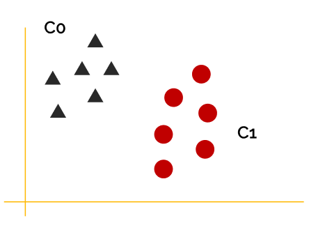

As we attempt to separate these classes through a hyperplane in multidimensional space, there can be many candidate lines that achieve this task, as illustrated below. The black line, blue line, and green line are perfectly viable candidates.

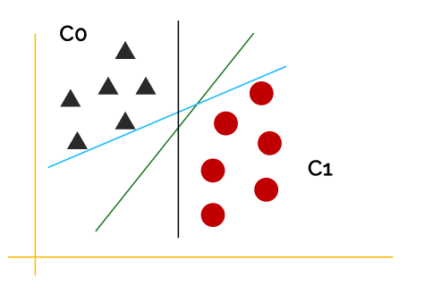

**Which of the 3 lines better differentiate the data into two classes?**

### **Key Points**

**The basic idea of SVC:** maximize the distance (margin) between the hyperplane and the nearest sample point. The best line is the line that, as much as possible, provides a maximally large margin between the two classes.

This is illustrated in the following figure:

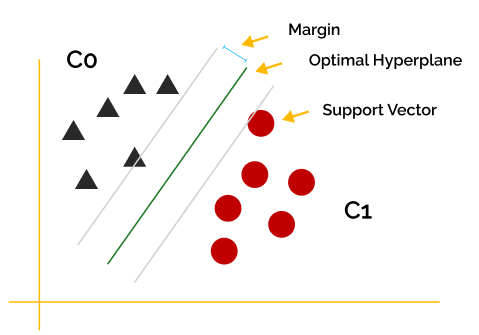

- **Optimal hyper-plane:** A hyperplane in two dimensions is simply a line that best separates the data. This line is like the decision boundary between the classes, as shown in the image above. In the case of three-dimensional data distribution, the hyperplane would be a two-dimensional surface and not a line.
- **Support Vector:** The closest points from both the classes to the hyperplane are called support vectors. Using the support vectors, the algorithm maximizes the margin between classes. By any means, if the support vectors are changed, the position of the hyperplane will also change.
- **Margin:** The distance between the support vectors and the hyperplane is called a margin.

### Additional: Math intuition behind SVM

In a two-dimension space we can visualize this as a line and let’s assume that all of our input points can be completely separated by one line. The equation of the separating hyperplane is as follow:

$w⋅x−b=0$

Where the coefficients ($w$) that determine the slope of the line and the intercept ($b$) are found by the learning algorithm, and x1 and x2 are the two input variables. That equation is from basic linear equation ($y = mx + c= 0$). Given a data point $w$, if $w⋅x$ is evaluated to to be bigger than $b$, it belongs to a corresponding class. If it is evaluated to be less than $b$, then it belongs to another class.

- A value close to the line returns a value close to zero and the point may be difficult to classify.

```python
# import svm model
from sklearn import svm

# create a svm Classifier
model_svc = svm.SVC()

# train the model
model_svc.fit(X_train, y_train)
```

```
SVC()
```

## Model Prediction

The ".predict()" method allows us to predict the labels from a new data set with the model being trained. This method accepts only one argument (new data) and returns the value (label for classification) learned for each of its objects. The parameters entered are:

- `X`: data to be predicted, for example, in general is `X_test`.

```python
# predict the response
y_pred = model_svc.predict(X_test)
```

```python
len(y_pred)
```

```
931
```

Notice that the model is trained only on the training set. The model is tested on the test set which the model has never seen before. This provides a more accurate evaluation on how the model will generalize to new data. We then compute the accuracy by comparing the actual test set values ("ground truth") and predicted values.

## Model Evaluation: Accuracy

All estimators installed in `sklearn` implement the `.score()` method. This score ranges between 0 and 1, with a higher score indicating a better match.

**In the case of classification, this corresponds to the accuracy score.** Accuracy is the proportion of cases that are correctly identified out of all cases. It is common practice to compare model performance based on training and testing data.

$$Accuracy = {\text{Number of correct predictions} \over \text{Total number of predictions}}.$$

```python
# train accuracy
model_svc.score(X_train, y_train)
```

```
0.6563675443310049
```

```python
# test accuracy
model_svc.score(X_test, y_test)
```

```
0.6552094522019334
```

Alternatively,

```python
# import scikit-learn metrics module
from sklearn import metrics

# model accuracy
print("Accuracy:", metrics.accuracy_score(y_test, y_pred))
```

```
Accuracy: 0.6552094522019334
```

## Model Improvement: Tuning Hyperparameters SVC

Every data analyst and scientist wants the best model for a case given the resources available: computation, money, and time.

Effective hyperparameter search is the missing piece of the puzzle that will assist us in our quest to find the best hyperparameter configuration that will score the highest on the metrics we care about in test data.

[figure not shown]

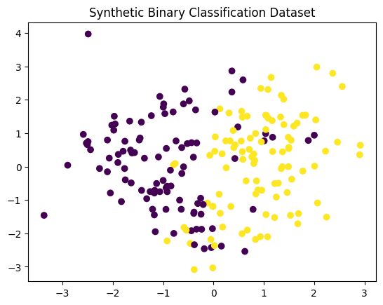

```python
# load data for explanation
bin_df = pd.read_csv("data_input/binary_classification.csv")

X = bin_df[["X1", "X2"]].values
y = bin_df["Target"].values


plt.title("Synthetic Binary Classification Dataset")
plt.scatter(bin_df["X1"], bin_df["X2"], c=bin_df["Target"]);
```

### Reguralization (C)

[figure not shown]

By default, Support Vector Machine implements Hard Margin SVM. It works well only if our data is linearly separable. Hard Margin SVM does not allow any misclassification to happen. It tries to find the best hyperplane that can separate the data.

In case our data is non-separable/ nonlinear then the Hard Margin SVM will not return any hyperplane as it will not be able to separate the data. This is where Soft Margin SVM comes into the picture.

Soft margin SVM allows some misclassification to happen by relaxing the hard constraints of Support Vector Machine. **Soft margin SVM is implemented with the help of the Regularization parameter (C).**

**Regularization parameter (C)**: It tells us how much misclassification we want to avoid.

- Hard margin SVM generally has large values of C.
- Soft margin SVM generally has small values of C.

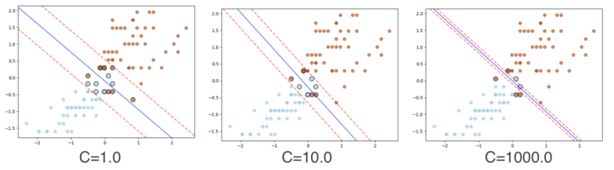

Now that we know what the Regularization parameter (C) does, we need to understand its relation with Support Vector Machine.

**Relation between Regularization parameter (C) and SVM**

- As the value of C increases the margin decreases (Hard SVM).
- If the values of C are very small the margin increases (Soft SVM).

*To simplify, when C is large the SVM tends to be overfitting, while when C is small the SVM tends to be underfitting.*

```python
# a simple custom plotting utility (classification)
from helper import create_plot_svc
```

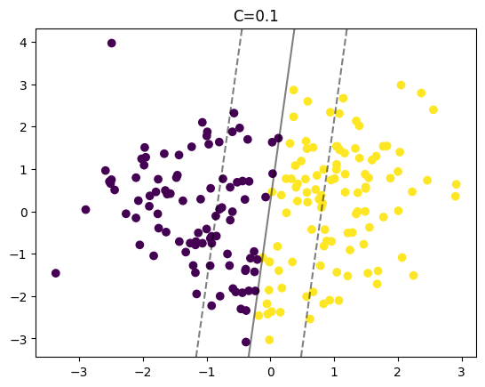

```python
clf = svm.SVC(kernel='linear', C=0.1).fit(X, y)
y_pred = clf.predict(X)

plt.title('C=0.1')
plt.scatter(X[:, 0], X[:, 1], c=y_pred)
create_plot_svc(clf)
```

```python
print("Accuracy:", metrics.accuracy_score(y, y_pred))
```

```
Accuracy: 0.87
```

### Kernel

When dealing with nonlinear data, Support Vector Machine transforms it into a higher dimension where it may be linearly separated. Support Vector Machine does this by utilizing various **Kernel** settings. With kernel, we can choose from a number of alternatives, including **"linear," "rbf," "poly,"** and others (the default value is "rbf"). RBF and poly are helpful in this case for non-linear hyper-plane.

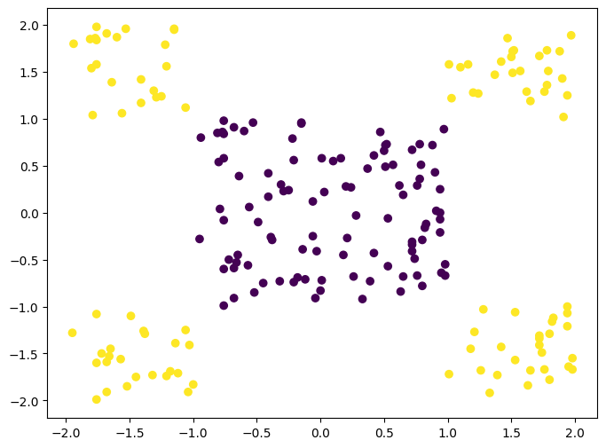

```python
# create custom dataset
circle_data = pd.read_csv('data_input/circle_data.csv')

plt.figure(figsize = (8, 6))
plt.scatter(circle_data["x"], circle_data["y"], c = circle_data["label"])
```

When dealing with nonlinear data, Support Vector Machine converts them into higher dimensional ones that can be separated linearly. The Support Vector Machine does this by leveraging various **Kernel** settings. With the kernel, we can choose from a number of alternatives, including **"linear", "rbf", "poly",** and others (default value is "rbf"). We can solve this using the kernel.

**Linear**

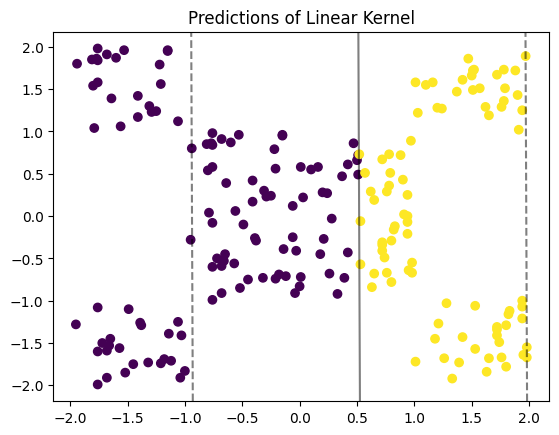

```python
clf = svm.SVC(kernel='linear').fit(circle_data[['x','y']].values, circle_data['label'].values)
y_pred = clf.predict(circle_data[['x','y']].values)

plt.title("Predictions of Linear Kernel")
plt.scatter(circle_data["x"], circle_data["y"], c=y_pred)
create_plot_svc(clf)
```

```python
print("Accuracy:", metrics.accuracy_score(circle_data["label"].values, y_pred))
```

```
Accuracy: 0.6
```

**Poly**

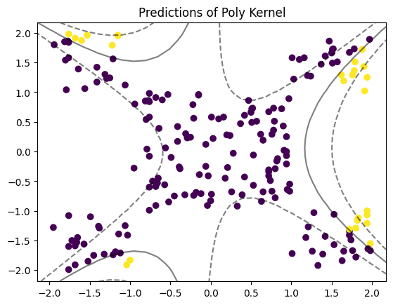

```python
clf = svm.SVC(kernel='poly').fit(circle_data[['x','y']].values, circle_data['label'].values)
y_pred = clf.predict(circle_data[['x','y']].values)

plt.title("Predictions of Poly Kernel")
plt.scatter(circle_data["x"], circle_data["y"], c=y_pred)
create_plot_svc(clf)
```

```python
print("Accuracy:", metrics.accuracy_score(circle_data["label"].values, y_pred))
```

```
Accuracy: 0.63
```

**Radial Basis Function (RBF) Kernel**

*RBF behave like the weighted nearest neighbor, the closest observation have a lot of influence.*

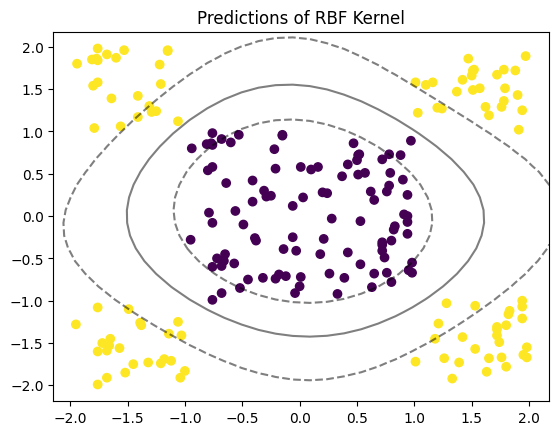

```python
clf = svm.SVC(kernel='rbf').fit(circle_data[['x','y']].values, circle_data['label'].values)
y_pred = clf.predict(circle_data[['x','y']].values)

plt.title("Predictions of RBF Kernel")
plt.scatter(circle_data["x"], circle_data["y"], c=y_pred)
create_plot_svc(clf)
```

```python
print("Accuracy:", metrics.accuracy_score(circle_data["label"].values, y_pred))
```

```
Accuracy: 1.0
```

### Gamma

The Gamma values used in SVM are similar to the C values. Gamma is a parameter for non-linear hyperplanes. The gamma parameter defines how far the influence of a single training example reaches, with low values meaning 'far' and high values meaning 'close'. The gamma parameters can be seen as the inverse of the radius of influence of samples selected by the model as support vectors.

- **Large Gamma:** The decision boundary will be influenced by fewer data points. As a result, overfitting results from the decision boundary being non-linear.
- **Small Gamma:** The decision boundary will be influenced by more data points. The decision boundary is hence more generic.

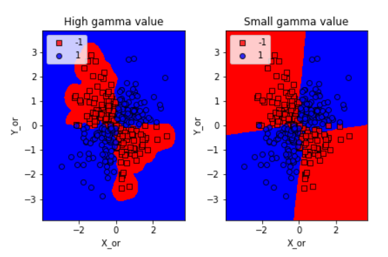

#### Tuning Gamma

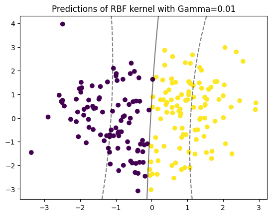

```python
clf = svm.SVC(kernel='rbf', gamma=0.01).fit(X, y)
y_pred = clf.predict(X)

plt.title("Predictions of RBF kernel with Gamma=0.01")
plt.scatter(X[:, 0], X[:, 1], c=y_pred)
create_plot_svc(clf)
```

```python
print("Accuracy:", metrics.accuracy_score(y, y_pred))
```

```
Accuracy: 0.88
```

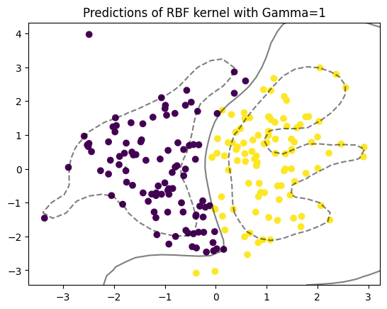

```python
clf = svm.SVC(kernel='rbf', gamma=1).fit(X, y)
y_pred = clf.predict(X)

plt.title("Predictions of RBF kernel with Gamma=1")
plt.scatter(X[:, 0], X[:, 1], c=y_pred)
create_plot_svc(clf)
```

```python
print("Accuracy:", metrics.accuracy_score(y, y_pred))
```

```
Accuracy: 0.91
```

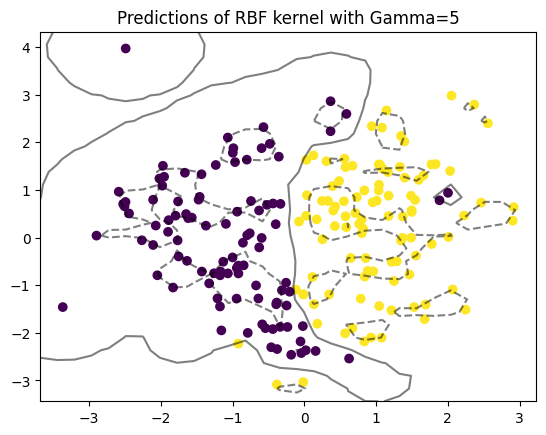

```python
clf = svm.SVC(kernel='rbf', gamma=5).fit(X, y)
y_pred = clf.predict(X)

plt.title("Predictions of RBF kernel with Gamma=5")
plt.scatter(X[:, 0], X[:, 1], c=y_pred)
create_plot_svc(clf)
```

```python
print("Accuracy:", metrics.accuracy_score(y, y_pred))
```

```
Accuracy: 0.93
```

## Tuning Model

```python
# try to use scaled features
model_svc_tuned = svm.SVC().fit(X_train_ss, y_train)

print(model_svc_tuned.score(X_train_ss, y_train))
print(model_svc_tuned.score(X_test_ss, y_test))
```

```
0.7813003761418592
0.7916219119226638
```

### Insight: After Use Standarized Features (`X_train_ss`)

It looks like you've used a support vector machine (SVM) classifier and observed changes in accuracy after applying standard scaling to the features. Let's break down the insights:

Initial Accuracy:

- Training Accuracy: 65.63%
- Testing Accuracy: 65.52%

After Standard Scaling:

- Training Accuracy: Improved to 78.13%
- Testing Accuracy: Improved to 79.16%

**Result**:

- **Scaling Impact**: The increase in accuracy after applying standard scaling suggests that the SVM model benefits from having features on a similar scale. SVMs are sensitive to the scale of input features, so standardizing them (scaling to mean = 0 and standard deviation = 1) often improves model performance. When features are on different scales, the SVM might give more importance to features with larger scales. Standard scaling ensures that all features contribute equally.
- **Overfitting/Underfitting**: The fact that the testing accuracy improved suggests that scaling helped in generalization. It's important to check for overfitting or underfitting; a significant gap between training and testing accuracy might indicate overfitting, while low accuracies on both may indicate underfitting.

```python
model_svc_tuned.get_params()
```

```
{'C': 1.0,
 'break_ties': False,
 'cache_size': 200,
 'class_weight': None,
 'coef0': 0.0,
 'decision_function_shape': 'ovr',
 'degree': 3,
 'gamma': 'scale',
 'kernel': 'rbf',
 'max_iter': -1,
 'probability': False,
 'random_state': None,
 'shrinking': True,
 'tol': 0.001,
 'verbose': False}
```

### Trial to Tuning Others Hyperparameters

```python
model_svc_hyper = svm.SVC(C = 1000, kernel = 'rbf', gamma = 0.01)

model_svc_hyper.fit(X_train, y_train)

print(model_svc_hyper.score(X_train, y_train))
print(model_svc_hyper.score(X_test, y_test))
```

```
0.7716281569048898
0.7862513426423201
```

### Additional - GridSearchCV for Hyperparameter Tuning

`GridSearchCV` is a tool from `sklearn` used for hyperparameter tuning in machine learning. It helps us to find good hyperparameter combinations for our model in a systematic way, reducing the risk of overfitting and improving model performance.

```python
from sklearn.model_selection import GridSearchCV

parameters = {'C':[1, 10, 100, 1000],
              'gamma':['scale', 0.1, 0.01]}

svc = svm.SVC()
gridsearch = GridSearchCV(svc, parameters)

gridsearch.fit(X_train, y_train)

pd.DataFrame({'rank' : gridsearch.cv_results_['rank_test_score'],
              'param':  gridsearch.cv_results_['params'],
              'score':  gridsearch.cv_results_['mean_test_score']}).sort_values('rank')
```

|  | rank | param | score |
| --- | --- | --- | --- |
| 11 | 1 | {'C': 1000, 'gamma': 0.01} | 0.762221 |
| 4 | 2 | {'C': 10, 'gamma': 0.1} | 0.750668 |
| 7 | 3 | {'C': 100, 'gamma': 0.1} | 0.750133 |
| 8 | 4 | {'C': 100, 'gamma': 0.01} | 0.745564 |
| 10 | 5 | {'C': 1000, 'gamma': 0.1} | 0.744223 |
| 1 | 6 | {'C': 1, 'gamma': 0.1} | 0.740723 |
| 9 | 7 | {'C': 1000, 'gamma': 'scale'} | 0.732402 |
| 5 | 8 | {'C': 10, 'gamma': 0.01} | 0.720849 |
| 6 | 9 | {'C': 100, 'gamma': 'scale'} | 0.709029 |
| 3 | 10 | {'C': 10, 'gamma': 'scale'} | 0.701508 |
| 2 | 11 | {'C': 1, 'gamma': 0.01} | 0.693985 |
| 0 | 12 | {'C': 1, 'gamma': 'scale'} | 0.656368 |

# SVM In Regression: Support Vector Regressor

Support Vector Machines (SVMs) are well known in classification problems. So, can svm be used for predict discrete values or regression?

The answer is yes -- by using the same principle of SVMs, we can use SVMs for regression problems. The only difference is that instead of using the hyperplane to separate the classes, we use the hyperplane to predict the value of the target variable, a method that goes by the name of Support Vector Regression (SVR).

**Why SVR?**

How does SVR compares to simple regression? In simple regression, we aim to reduce the error rate. While using SVR, **we attempt to keep the error within predetermined limits**.

[figure not shown]

SVR has the following advantages,

- SVR performs lower processing compared to other regression techniques.
- Has excellent generalization ability, with high prediction accuracy.

# Machine Learning Workflow: Regression

## Load Data: Diamonds Dataset

"What is the expected price of a diamond given its carat weight, cut, color, and clarity?"

For the following practice, we shall use the diamonds dataset. This classic dataset contains physical attributes and prices of many diamonds. They describe characteristics of the diamond. The dataset comprises of 9 features (carat, cut, color, clarity, x, y, z, depth, table) and a target (price).

```python
diamonds = pd.read_csv("data_input/diamonds-clean.csv")
diamonds
```

|  | carat | cut | color | clarity | depth | table | price | x | y | z |
| --- | --- | --- | --- | --- | --- | --- | --- | --- | --- | --- |
| 0 | 0.63 | Fair | 5 | VS | 65.7 | 60.0 | 2011 | 5.41 | 5.31 | 3.52 |
| 1 | 2.00 | Fair | 0 | SI | 66.4 | 55.0 | 11189 | 7.82 | 7.67 | 5.15 |
| 2 | 0.48 | Fair | 4 | SI | 56.4 | 59.0 | 994 | 5.28 | 5.26 | 2.97 |
| 3 | 2.04 | Fair | 1 | SI | 66.6 | 56.0 | 9802 | 7.80 | 7.77 | 5.19 |
| 4 | 0.71 | Fair | 0 | SI | 65.5 | 61.0 | 1409 | 5.54 | 5.49 | 3.61 |
| ... | ... | ... | ... | ... | ... | ... | ... | ... | ... | ... |
| 2692 | 0.38 | Very Good | 4 | VS | 60.9 | 56.0 | 800 | 4.67 | 4.72 | 2.86 |
| 2693 | 0.58 | Very Good | 3 | VVS | 62.1 | 58.0 | 1872 | 5.35 | 5.40 | 3.34 |
| 2694 | 1.51 | Very Good | 2 | VVS | 61.5 | 58.0 | 12981 | 7.30 | 7.39 | 4.52 |
| 2695 | 0.30 | Very Good | 4 | SI | 62.1 | 61.0 | 500 | 4.25 | 4.29 | 2.65 |
| 2696 | 1.01 | Very Good | 1 | SI | 63.5 | 57.0 | 4244 | 6.35 | 6.37 | 4.04 |

2697 rows × 10 columns

**Data Description**

- `price`: price in US dollars
- `carat`: weight of the diamond
- `cut`: quality of the cut (Fair, Good, Very Good, Premium, Ideal)
- `color`: diamond colour, from 0 (worst) to 6 (best)
- `clarity`: a measurement of how clear the diamond is (I1 (worst), SI, VS, VVS, IF (best))
- `x`: length in mm
- `y`: width in mm
- `z`: depth in mm
- `depth`: total depth percentage = z / mean(x, y) = 2 * z / (x + y) (43--79)
- `table`: width of top of diamond relative to widest point (43-95)

## Exploratory Data Analysis

How is the data type of each column in the data? Is it appropriate?

```python
diamonds.info()
```

```
<class 'pandas.core.frame.DataFrame'>
RangeIndex: 2697 entries, 0 to 2696
Data columns (total 10 columns):
 #   Column   Non-Null Count  Dtype
---  ------   --------------  -----
 0   carat    2697 non-null   float64
 1   cut      2697 non-null   object
 2   color    2697 non-null   int64
 3   clarity  2697 non-null   object
 4   depth    2697 non-null   float64
 5   table    2697 non-null   float64
 6   price    2697 non-null   int64
 7   x        2697 non-null   float64
 8   y        2697 non-null   float64
 9   z        2697 non-null   float64
dtypes: float64(6), int64(2), object(2)
memory usage: 210.8+ KB
```

What are the characteristics of our data? Such as the dimension, carat, price of the diamonds

```python
diamonds.describe()
```

|  | carat | color | depth | table | price | x | y | z |
| --- | --- | --- | --- | --- | --- | --- | --- | --- |
| count | 2697.000000 | 2697.000000 | 2697.000000 | 2697.000000 | 2697.000000 | 2697.000000 | 2697.000000 | 2697.000000 |
| mean | 0.813745 | 3.411568 | 61.793437 | 57.449462 | 4068.796440 | 5.762896 | 5.765143 | 3.559132 |
| std | 0.480712 | 1.711278 | 1.440168 | 2.173359 | 4117.797273 | 1.132582 | 1.124426 | 0.709357 |
| min | 0.230000 | 0.000000 | 55.800000 | 49.000000 | 355.000000 | 0.000000 | 0.000000 | 0.000000 |
| 25% | 0.400000 | 2.000000 | 61.100000 | 56.000000 | 957.000000 | 4.730000 | 4.740000 | 2.920000 |
| 50% | 0.710000 | 3.000000 | 61.900000 | 57.000000 | 2488.000000 | 5.710000 | 5.730000 | 3.550000 |
| 75% | 1.060000 | 5.000000 | 62.500000 | 59.000000 | 5443.000000 | 6.560000 | 6.560000 | 4.050000 |
| max | 3.240000 | 6.000000 | 70.000000 | 68.000000 | 18741.000000 | 9.440000 | 9.400000 | 5.850000 |

**Insight :**

- Diamond price range from 355 to 18741 USD
- Diamond dimension x, y, z start from 0

### Visualize the Data

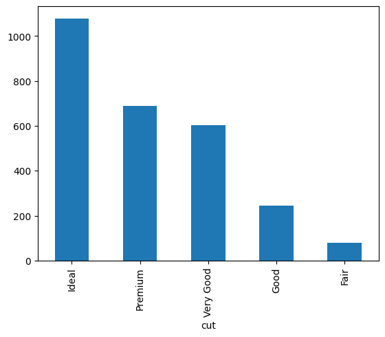

```python
diamonds['cut'].value_counts().plot(kind='bar')
```

If we want to see the distribution of values in each column, we can do it as follows. This can be useful in data analysis and data visualization tasks to gain insights into the data, identify patterns, and understand the characteristics of the data in each column.

```
array([[<Axes: title={'center': 'carat'}>,
        <Axes: title={'center': 'color'}>,
        <Axes: title={'center': 'depth'}>],
       [<Axes: title={'center': 'table'}>,
        <Axes: title={'center': 'price'}>, <Axes: title={'center': 'x'}>],
       [<Axes: title={'center': 'y'}>, <Axes: title={'center': 'z'}>,
        <Axes: >]], dtype=object)
```

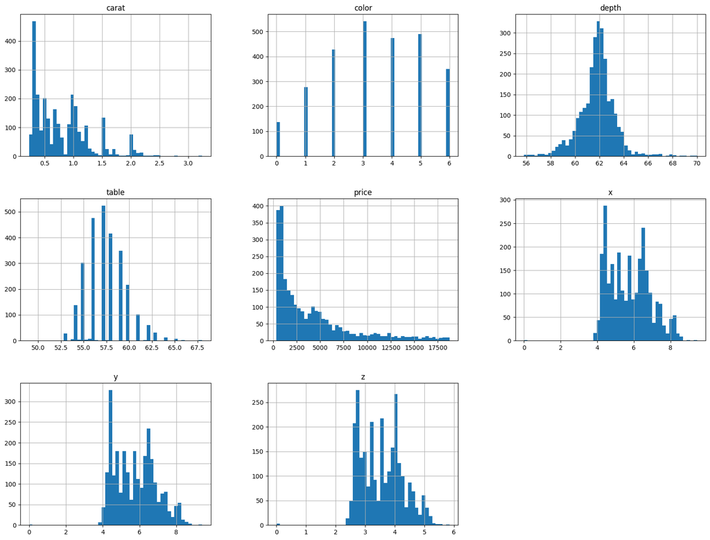

```python
diamonds.hist(bins=50, figsize=(20,15))
```

> **NOTES**:
> - In summary, hist(bins=50, figsize=(20,15)) will generate a histogram with 50 bins for the data, and the resulting plot will have a width of 20 inches and a height of 15 inches.
> - If the input is a DataFrame (df) used for df.hist(), it will produce histograms for the total number of numeric columns it contains.

How is the correlation between table (width of top diamond) and the price of a diamond?

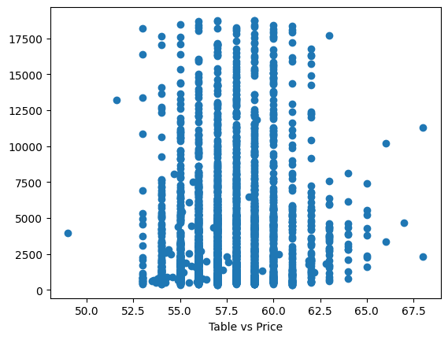

```python
plt.scatter(diamonds['table'], diamonds['price'])
plt.xlabel('Table vs Price')
```

**Insight:** it turns out that the table doesn't really affect the price. So it doesn't really have a strong effect on diamond prices

How is the correlation between carat and the price of a diamond?

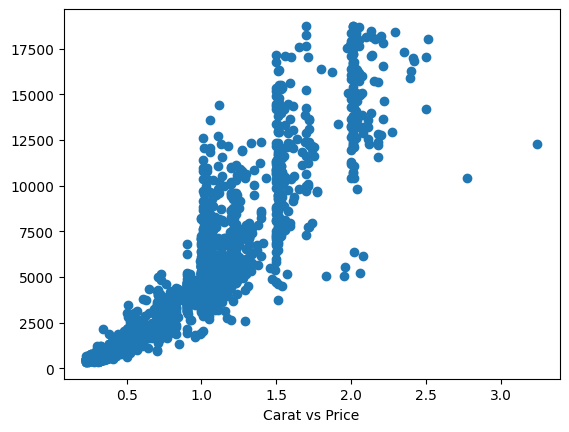

```python
plt.scatter(diamonds['carat'], diamonds['price'])
plt.xlabel('Carat vs Price')
```

**Insight:** it turns out that carat really affects the price, the higher the carat value, the higher the price. So, carat has a strong correlation with diamond prices

As we can see from the chart above, there is a clear relationship between the two variables, with the diamond price increasing as the carat value increases. *Then, we will try to take `carat` as a feature/predictor (independent) and `price` as the target variable (dependent)*